# Project 6 : Material manufacturing

### Submitted by Aman Kumar Agarwal

### Data Description :

The actual concrete compressive strength (MPa) for a given mixture under a specific age (days) was determined from laboratory. Data is in raw form (not scaled).The data has 8 quantitative input variables, and 1 quantitative output variable, and 1030 instances (observations).

### Context :

Concrete is the most important material in civil engineering. The concrete compressive strength is a highly nonlinear function of age and ingredients. These ingredients include cement, blast furnace slag, fly ash, water, superplasticizer, coarse aggregate, and fine aggregate.

### Dataset : https://archive.ics.uci.edu/ml/datasets/concrete+compressive+strength

# Attribute Information

1. **Cement :** measured in kg in a m3 mixture
2. **Blast :** measured in kg in a m3 mixture
3. **Fly ash :** measured in kg in a m3 mixture
4. **Water :** measured in kg in a m3 mixture
5. **Superplasticizer :** measured in kg in a m3 mixture
6. **Coarse Aggregate :** measured in kg in a m3 mixture
7. **Fine Aggregate :** measured in kg in a m3 mixture
8. **Age :** day (1~365)
9. **Concrete compressive strength:** measured in MPa

# Part 1 : Data Preprocessing

```python
import numpy as np
import pandas as pd
import matplotlib.pyplot as plt
import seaborn as sns
%matplotlib inline
sns.set(color_codes=True)
import warnings
warnings.filterwarnings("ignore", category=FutureWarning)
warnings.filterwarnings("ignore", category=RuntimeWarning)
```

## Loading the dataset

```python
dataset = pd.read_csv("D:/Study/AI-ML/Dataset/concrete.csv")
```

## Overview of the data

```python
dataset.head(5)
```

|  | cement | slag | ash | water | superplastic | coarseagg | fineagg | age | strength |
| --- | --- | --- | --- | --- | --- | --- | --- | --- | --- |
| 0 | 141.3 | 212.0 | 0.0 | 203.5 | 0.0 | 971.8 | 748.5 | 28 | 29.89 |
| 1 | 168.9 | 42.2 | 124.3 | 158.3 | 10.8 | 1080.8 | 796.2 | 14 | 23.51 |
| 2 | 250.0 | 0.0 | 95.7 | 187.4 | 5.5 | 956.9 | 861.2 | 28 | 29.22 |
| 3 | 266.0 | 114.0 | 0.0 | 228.0 | 0.0 | 932.0 | 670.0 | 28 | 45.85 |
| 4 | 154.8 | 183.4 | 0.0 | 193.3 | 9.1 | 1047.4 | 696.7 | 28 | 18.29 |

```python
dataset.info()
```

```
<class 'pandas.core.frame.DataFrame'>
RangeIndex: 1030 entries, 0 to 1029
Data columns (total 9 columns):
cement          1030 non-null float64
slag            1030 non-null float64
ash             1030 non-null float64
water           1030 non-null float64
superplastic    1030 non-null float64
coarseagg       1030 non-null float64
fineagg         1030 non-null float64
age             1030 non-null int64
strength        1030 non-null float64
dtypes: float64(8), int64(1)
memory usage: 72.5 KB
```

```python
dataset.describe()
# slag, ash and age seem to have outliers as their mean and the 50 percentile differ by a significant margin.
```

|  | cement | slag | ash | water | superplastic | coarseagg | fineagg | age | strength |
| --- | --- | --- | --- | --- | --- | --- | --- | --- | --- |
| count | 1030.000000 | 1030.000000 | 1030.000000 | 1030.000000 | 1030.000000 | 1030.000000 | 1030.000000 | 1030.000000 | 1030.000000 |
| mean | 281.167864 | 73.895825 | 54.188350 | 181.567282 | 6.204660 | 972.918932 | 773.580485 | 45.662136 | 35.817961 |
| std | 104.506364 | 86.279342 | 63.997004 | 21.354219 | 5.973841 | 77.753954 | 80.175980 | 63.169912 | 16.705742 |
| min | 102.000000 | 0.000000 | 0.000000 | 121.800000 | 0.000000 | 801.000000 | 594.000000 | 1.000000 | 2.330000 |
| 25% | 192.375000 | 0.000000 | 0.000000 | 164.900000 | 0.000000 | 932.000000 | 730.950000 | 7.000000 | 23.710000 |
| 50% | 272.900000 | 22.000000 | 0.000000 | 185.000000 | 6.400000 | 968.000000 | 779.500000 | 28.000000 | 34.445000 |
| 75% | 350.000000 | 142.950000 | 118.300000 | 192.000000 | 10.200000 | 1029.400000 | 824.000000 | 56.000000 | 46.135000 |
| max | 540.000000 | 359.400000 | 200.100000 | 247.000000 | 32.200000 | 1145.000000 | 992.600000 | 365.000000 | 82.600000 |

## Data Cleaning and Exploratory Data Analysis (EDA)

```python
dataset.isnull().sum()
```

```
cement          0
slag            0
ash             0
water           0
superplastic    0
coarseagg       0
fineagg         0
age             0
strength        0
dtype: int64
```

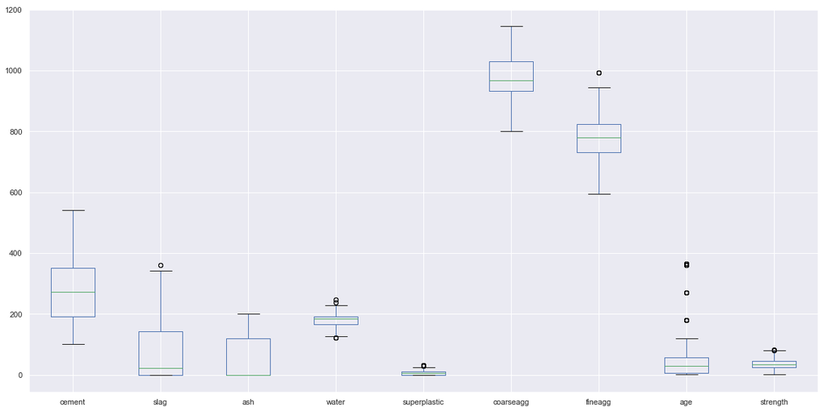

```python
dataset.plot(kind="box",figsize=(20,10))
```

### 1. Univariate Analysis.

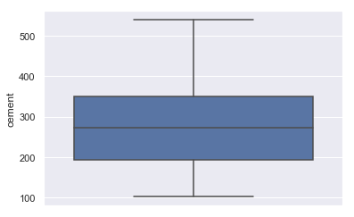

```python
sns.boxplot(y="cement",data=dataset)
```

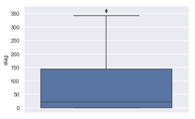

```python
sns.boxplot(y="slag",data=dataset)
```

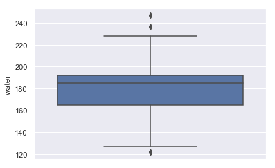

```python
sns.boxplot(y="water",data=dataset)
```

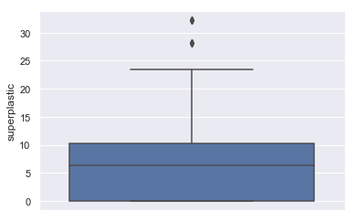

```python
sns.boxplot(y="superplastic",data=dataset)
```

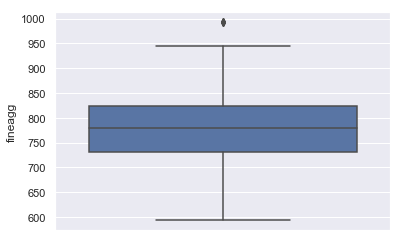

```python
sns.boxplot(y="fineagg",data=dataset)
```

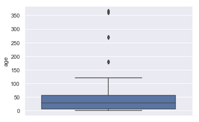

```python
sns.boxplot(y="age",data=dataset)
```

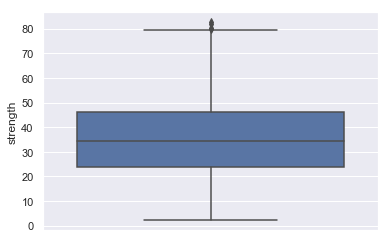

```python
sns.boxplot(y="strength",data=dataset)
```

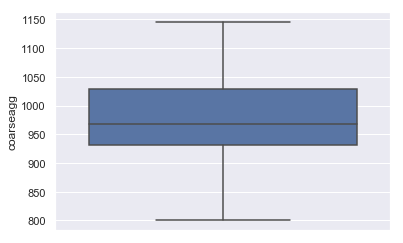

```python
sns.boxplot(y="coarseagg",data=dataset)
```

```python
# Handling outliers
for col in dataset.columns[:10]:
    q1 = dataset[col].quantile(0.25)
    q3 = dataset[col].quantile(0.75)

    iqr = q3 - q1

    low = q1 - (1.5*iqr)
    high = q3 + (1.5*iqr)

    dataset.loc[(dataset[col]<low) | (dataset[col] > high),col] = dataset[col].mean()
```

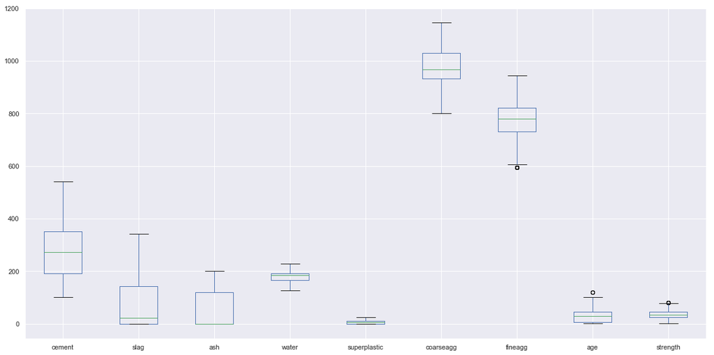

```python
dataset.plot(kind="box",figsize=(20,10))
```

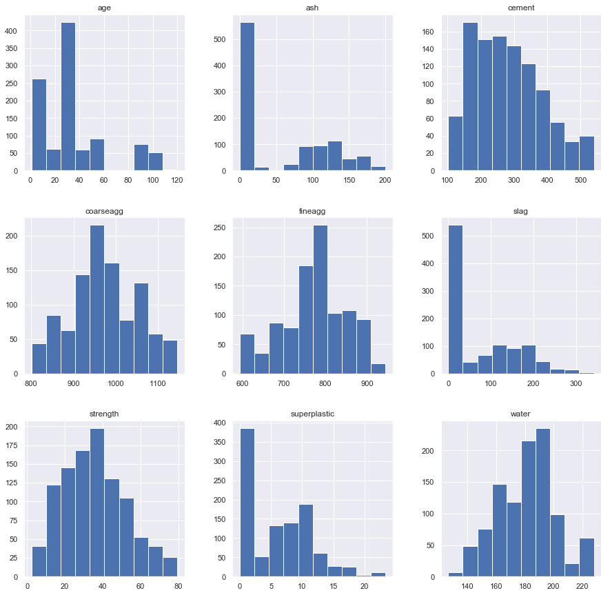

```python
dataset.hist(figsize=(15,15))
plt.show()
# Skewness exists among the different attributes.
```

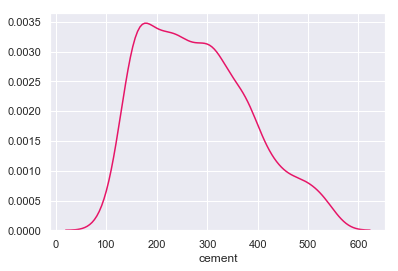

```python
sns.distplot(dataset['cement'],color="#E61567",hist=False)
# Cement has more or less a normal distribution
```

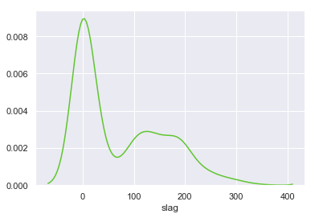

```python
sns.distplot(dataset['slag'],color="#5EC62D",hist=False)
# Slag looks like a mixture of 2 gaussians
```

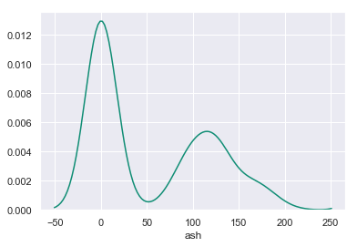

```python
sns.distplot(dataset['ash'],color="#0F8D74",hist=False)
# Probability of 2 different gaussians mixed in the data
```

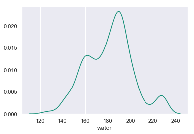

```python
sns.distplot(dataset['water'],color="#148F77",hist=False)
# Existence of multiple gaussians in the water attribute
```

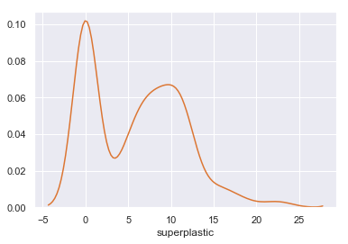

```python
sns.distplot(dataset['superplastic'],color="#DC7633",hist=False)
```

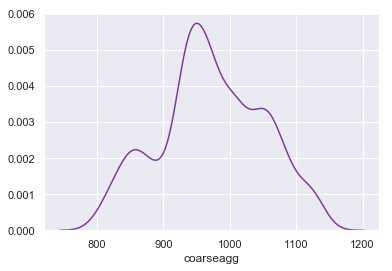

```python
sns.distplot(dataset['coarseagg'],color="#7D3C98",hist=False)
# Multiple gaussians existence
```

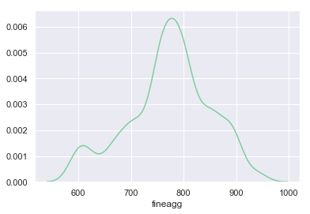

```python
sns.distplot(dataset['fineagg'],color="#7DCEA0",hist=False)
```

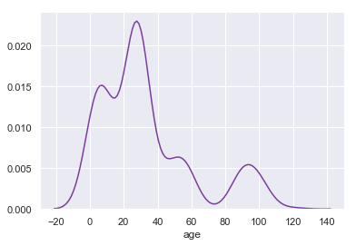

```python
sns.distplot(dataset['age'],color="#7D3C98",hist=False)
# Different gaussians mixed together
```

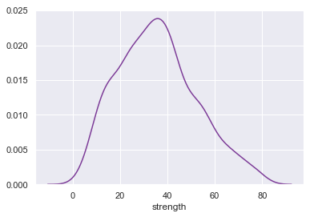

```python
sns.distplot(dataset['strength'],color="#7D3C98",hist=False)
```

### 2. Bivariate and Multivariate Analysis.

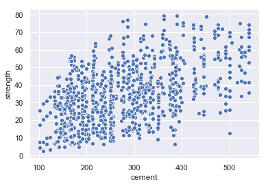

```python
sns.scatterplot(x=dataset['cement'],y=dataset['strength'])
# There exists scattered but linear relationship between cement and strength
```

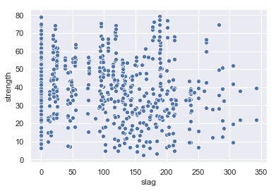

```python
sns.scatterplot(x=dataset['slag'],y=dataset['strength'])
# No linear relationship exists, probably not a good predictor for strength
```

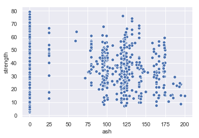

```python
sns.scatterplot(x=dataset['ash'],y=dataset['strength'])
# No clear relationship
```

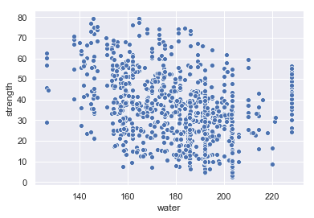

```python
sns.scatterplot(x=dataset['water'],y=dataset['strength'])
# Slight negative linear relationship exists between water and strength of the concrete.
```

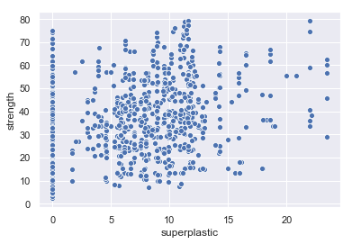

```python
sns.scatterplot(x=dataset['superplastic'],y=dataset['strength'])
# Slight positive relation
```

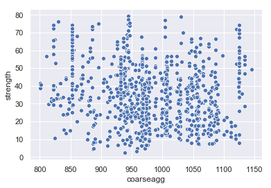

```python
sns.scatterplot(x=dataset['coarseagg'],y=dataset['strength'])
# No significant linear relation
```

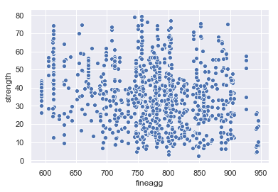

```python
sns.scatterplot(x=dataset['fineagg'],y=dataset['strength'])
# No significant linear relation
```

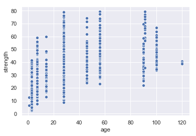

```python
sns.scatterplot(x=dataset['age'],y=dataset['strength'])
# Nominal positive relation exists as we see the strength tends to increase with the age.
```

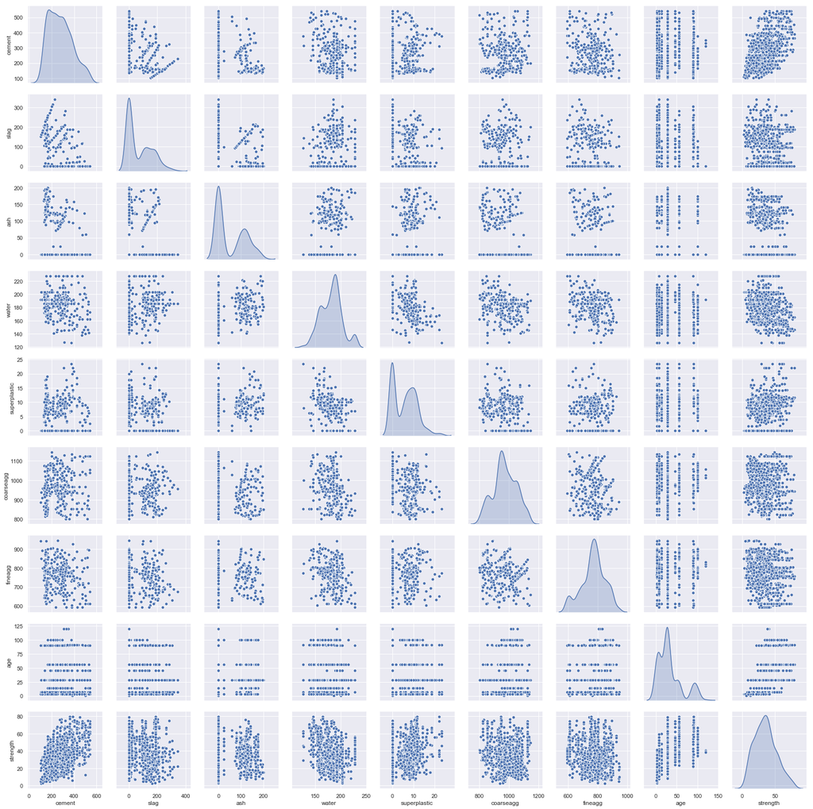

```python
sns.pairplot(dataset,diag_kind="kde")
```

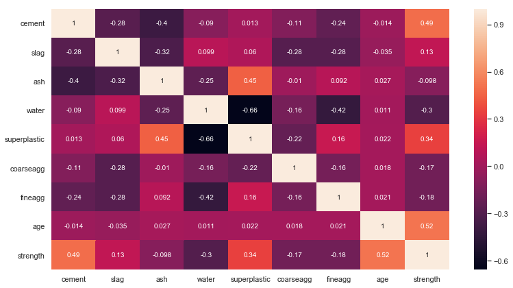

```python
corr = dataset.corr()
plt.figure(figsize=(13,7))
sns.heatmap(corr,annot=True)
plt.show()
# Shows that most of the independent variables are not related to each other.
```

# Part 2 : Splitting Data & Model Building

## Importing necessary libraries for model building

```python
from sklearn.model_selection import train_test_split # Library for splitting the dataset
from sklearn import svm
from scipy.stats import zscore
from sklearn.cluster import KMeans
from sklearn.tree import DecisionTreeRegressor
from sklearn.linear_model import LinearRegression
from scipy.spatial.distance import cdist
from sklearn.linear_model import Lasso,Ridge
```

## Transforming the data

```python
dataset_z = dataset.apply(zscore)
```

```python
X=dataset_z
```

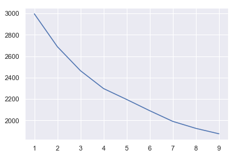

```python
clusters = range(1,10)
mean_distortions = []
for k in clusters:
    model = KMeans(n_clusters=k)
    model.fit(dataset_z)
    prediction = model.predict(dataset_z)
    mean_distortions.append(sum(np.min(cdist(X, model.cluster_centers_, 'euclidean'), axis=1)))
plt.plot(clusters,mean_distortions)

# The elbow diagram shows that the data is a mix of 6-7 gaussians.
```

```python
dataset_z.head(5)
```

|  | cement | slag | ash | water | superplastic | coarseagg | fineagg | age | strength |
| --- | --- | --- | --- | --- | --- | --- | --- | --- | --- |
| 0 | -1.339017 | 1.625292 | -0.847144 | 1.062459 | -1.090842 | -0.014398 | -0.305317 | -0.188562 | -0.349536 |
| 1 | -1.074790 | -0.365026 | 1.096078 | -1.132696 | 0.881980 | 1.388141 | 0.301063 | -0.689672 | -0.737237 |
| 2 | -0.298384 | -0.859675 | 0.648965 | 0.280557 | -0.086164 | -0.206121 | 1.127367 | -0.188562 | -0.390251 |
| 3 | -0.145209 | 0.476581 | -0.847144 | 2.252311 | -1.090842 | -0.526517 | -1.303237 | -0.188562 | 0.620322 |
| 4 | -1.209776 | 1.290056 | -0.847144 | 0.567092 | 0.571443 | 0.958372 | -0.963817 | -0.188562 | -1.054446 |

## Seperating independent and Dependent attributes

```python
# Splitting data on independent and target variables
X = dataset_z.iloc[:,0:8]
y = dataset_z.iloc[:,-1]
```

### Creating training, validation and test sets

```python
X_train, X_test, y_train, y_test = train_test_split(X,y,test_size = 0.2, random_state = 10)
```

```python
X_train,X_val,y_train,y_val = train_test_split(X_train,y_train,test_size=0.2,random_state=10)
```

## --------------------------------------------Decision Trees----------------------------------------------------

We start with Decision tree so that we can use the feature importances to decide on the important features and perform feature selection only on those attributes.

```python
DT_regressor = DecisionTreeRegressor(criterion="mse",max_depth=13,random_state=10)
DT_regressor.fit(X_train,y_train)
```

```
DecisionTreeRegressor(criterion='mse', max_depth=13, max_features=None,
           max_leaf_nodes=None, min_impurity_decrease=0.0,
           min_impurity_split=None, min_samples_leaf=1,
           min_samples_split=2, min_weight_fraction_leaf=0.0,
           presort=False, random_state=10, splitter='best')
```

```python
y_val_DT = DT_regressor.predict(X_val)
```

```python
DT_val_score = DT_regressor.score(X_val,y_val)
DT_val_score
```

```
0.7425291493885076
```

```python
DT_test_score = DT_regressor.score(X_test,y_test)
DT_test_score

# Test score and validation score are almost the same which signifies that the model is not overfit.
```

```
0.7833616179891956
```

```python
# Checking importances of attributes for feature selection
importances = DT_regressor.feature_importances_
```

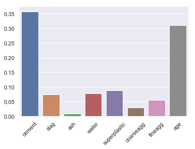

```python
cols= X.columns
sns.barplot(x=cols,y=importances)
plt.xticks(rotation=45)
```

```python
# Clearly ash and coarsagg have the least importance, therefore can be dropped.
new_attributes = X.drop(columns=['ash','coarseagg'])
```

```python
# Creating new training, validation and test sets with the new attributes after dropping ash.
X_train_2, X_test_2, y_train_2, y_test_2 = train_test_split(new_attributes,y,test_size = 0.2, random_state = 10)
X_train_2,X_val_2,y_train_2,y_val_2 = train_test_split(X_train_2,y_train_2,test_size=0.2,random_state=10)
```